# W6 STAT5003 RMD

Victor Z. Nygaard, vnyg7406

Last compiled on 28. januar, 2023

# 1.

We load in the required packages and data:

```r
library(caret)
library(class)
data(Sonar, package = "mlbench")
#Sonar %>% head()
```

We may create the 10-fold partition with `caret`, as well as apply the kNN with $k = 5$ over each of the created folds. Using knn, we may with one command also apply the fitted model of each of the folds, to the corresponding test fold, and get the predicted results as in `knn.preds`

```r
folds <- createFolds(Sonar$Class, k=10)
# apply 10-fold cross-validation
knn.preds <- lapply(folds, function(f) knn(train = Sonar[-f,-61],
                                           test = Sonar[f,-61],
                                           cl = Sonar$Class[-f],
                                           k = 5))
knn.preds
```

```
## $Fold01
##  [1] R M R R R R R R R M M M R M M M M R R M M
## Levels: M R
##
## $Fold02
##  [1] M R R M R M M R R R M M M M M M R M M M M
## Levels: M R
##
## $Fold03
##  [1] R M M M R R R R R R M M M M M M M M M M M M
## Levels: M R
##
## $Fold04
##  [1] R M R R R R R R R R M M M M M M M M M M
## Levels: M R
##
## $Fold05
##  [1] M M M R R R R M R R R M M M M M R M M M R
## Levels: M R
##
## $Fold06
##  [1] M R R R R R R R R R M M M M R M M M M M M
## Levels: M R
##
## $Fold07
##  [1] R M R R R R R R M M M M M R M M M M M M M
## Levels: M R
##
## $Fold08
##  [1] M R M R R R R R R R M M M M M R M M M M M
## Levels: M R
##
## $Fold09
##  [1] M R R R R R R R R R M M M R M M R M M M
## Levels: M R
##
## $Fold10
##  [1] R R R M R M R R R M M M M M M M R M M M
## Levels: M R
```

Using the example code, we may extract the values of the confusion matrices, as well as extract the accuracy directly.

```r
obs <- lapply(folds, function(x) Sonar$Class[x])
knn.metrics <- mapply(function(pred, obs) confusionMatrix(data = pred, reference = obs),
                      pred = knn.preds, obs = obs,
                      SIMPLIFY = FALSE)
knn.TP <- vapply(knn.metrics, function(cm) cm[["table"]][1, 1], numeric(1))
knn.FP <- vapply(knn.metrics, function(cm) cm[["table"]][1, 2], numeric(1))
knn.FN <- vapply(knn.metrics, function(cm) cm[["table"]][2, 1], numeric(1))
knn.TN <- vapply(knn.metrics, function(cm) cm[["table"]][2, 2], numeric(1))
knn.accuracy <- vapply(knn.metrics, function(cm) cm[["overall"]]["Accuracy"], numeric(1))
```

We get the accuracies

```r
knn.accuracy
```

```
##    Fold01    Fold02    Fold03    Fold04    Fold05    Fold06    Fold07    Fold08
## 0.7619048 0.7619048 0.8636364 0.9000000 0.6666667 0.9047619 0.8095238 0.8571429
##    Fold09    Fold10
## 0.8000000 0.8500000
```

We may also have calculated the accuracy from the confusion matrix values. To see this, lets calculate the specificity, sensitivity, as well as $F_1$ scores from the confusion matrix values.

```r
SensFunc <- function(TP, FN) TP/(TP+FN)
SpecFunc <- function(TN, FP) TN/(TN+FP)
PrecFunc <- function(TP, FP) TP/(TP+FP)
RecaFunc <- SensFunc

sensitivity_10fold <- SensFunc(knn.TP, knn.FN)
specificity_10fold <- SpecFunc(knn.TN, knn.FP)
precision_10fold <- PrecFunc(knn.TP, knn.FP)
recall_10fold <- RecaFunc(knn.TP, knn.FN)
F1_10fold <- 2*precision_10fold * recall_10fold / (precision_10fold + recall_10fold)
```

Printing the sensitivity, specificity and F1:

```r
sensitivity_10fold
```

```
##    Fold01    Fold02    Fold03    Fold04    Fold05    Fold06    Fold07    Fold08
## 0.7272727 0.9090909 1.0000000 0.9090909 0.7272727 0.9090909 0.9090909 0.9090909
##    Fold09    Fold10
## 0.7272727 0.9090909
```

```r
specificity_10fold
```

```
##    Fold01    Fold02    Fold03    Fold04    Fold05    Fold06    Fold07    Fold08
## 0.8000000 0.6000000 0.7000000 0.8888889 0.6000000 0.9000000 0.7000000 0.8000000
##    Fold09    Fold10
## 0.8888889 0.7777778
```

```r
F1_10fold
```

```
##    Fold01    Fold02    Fold03    Fold04    Fold05    Fold06    Fold07    Fold08
## 0.7619048 0.8000000 0.8888889 0.9090909 0.6956522 0.9090909 0.8333333 0.8695652
##    Fold09    Fold10
## 0.8000000 0.8695652
```

We see that there is a lot of variation in the metrics across the different folds.

#2. We may employ the $100$-fold cross validation as in the code above the for $10$-way, with kNN for $k = 5$

```r
#knnSensSpecF1 <- function(data, target, numFolds, k, )

folds_100 <- createFolds(Sonar$Class, k=100)
# apply 10-fold cross-validation
knn.preds_100 <- lapply(folds_100, function(f) knn(train = Sonar[-f,-61],
                                           test = Sonar[f,-61],
                                           cl = Sonar$Class[-f],
                                           k = 5))
```

and calculate the confusion matrix statistics

```r
obs_100 <- lapply(folds_100, function(x) Sonar$Class[x])
knn.metrics_100 <- mapply(function(pred, obs) confusionMatrix(data = pred, reference = obs),
                      pred = knn.preds_100, obs = obs_100,
                      SIMPLIFY = FALSE)
knn.TP_100 <- vapply(knn.metrics_100, function(cm) cm[["table"]][1, 1], numeric(1))
knn.FP_100 <- vapply(knn.metrics_100, function(cm) cm[["table"]][1, 2], numeric(1))
knn.FN_100 <- vapply(knn.metrics_100, function(cm) cm[["table"]][2, 1], numeric(1))
knn.TN_100 <- vapply(knn.metrics_100, function(cm) cm[["table"]][2, 2], numeric(1))
knn.accuracy_100 <- vapply(knn.metrics_100, function(cm) cm[["overall"]]["Accuracy"], numeric(1))

sensitivity_100fold <- SensFunc(knn.TP_100, knn.FN_100)
specificity_100fold <- SpecFunc(knn.TN_100, knn.FP_100)
precision_100fold <- PrecFunc(knn.TP_100, knn.FP_100)
recall_100fold <- RecaFunc(knn.TP_100, knn.FN_100)
F1_100fold <- 2*precision_100fold * recall_100fold / (precision_100fold + recall_100fold)
```

We may note that in calculating some of these quantities across $100$ folds, that we will sometime have no examples of one of $\mathopen{}\left\{{TP, FP, FN, TN}\right\}\mathclose{}$, and sometimes, even no occurrences of either of the regulatory terms in the denominator of sensitivity, specificity,… This manifests itself in the calculation of sensitivity, specificity, … as a division by zero (the quantity is undefined) which records as a `NaN`. For example looking at `specificity_100fold`:

```r
specificity_100fold
```

```
## Fold001 Fold002 Fold003 Fold004 Fold005 Fold006 Fold007 Fold008 Fold009 Fold010
##       1       1       1       0       1       1       0       1       1       0
## Fold011 Fold012 Fold013 Fold014 Fold015 Fold016 Fold017 Fold018 Fold019 Fold020
##       0       1       1       1       1       1       1       1       0       1
## Fold021 Fold022 Fold023 Fold024 Fold025 Fold026 Fold027 Fold028 Fold029 Fold030
##       0       1       1       1       1       1       1       1       1       1
## Fold031 Fold032 Fold033 Fold034 Fold035 Fold036 Fold037 Fold038 Fold039 Fold040
##       1       1       1       0       0       1       1       1       1       1
## Fold041 Fold042 Fold043 Fold044 Fold045 Fold046 Fold047 Fold048 Fold049 Fold050
##       1       1       0       1       0       1       0       1       1       1
## Fold051 Fold052 Fold053 Fold054 Fold055 Fold056 Fold057 Fold058 Fold059 Fold060
##       1       0       1       0       1       1       1       0       1     NaN
## Fold061 Fold062 Fold063 Fold064 Fold065 Fold066 Fold067 Fold068 Fold069 Fold070
##       1       1       0       1       1       0       1       1       1       1
## Fold071 Fold072 Fold073 Fold074 Fold075 Fold076 Fold077 Fold078 Fold079 Fold080
##       0       1       1       1       1       1       0       1       0     NaN
## Fold081 Fold082 Fold083 Fold084 Fold085 Fold086 Fold087 Fold088 Fold089 Fold090
##       0       1       1       0       1     NaN       1       1       1       1
## Fold091 Fold092 Fold093 Fold094 Fold095 Fold096 Fold097 Fold098 Fold099 Fold100
##       1       1       1       1       0       1       1       1       1       0
```

which records three such `NaN`s. We will later be warned by `stat_bin` of this occurance, with `stat_bin` taking out these values.

We may create a data frame to visualise the results. Note that given that there are 208 rows in `Sonar`, it is no longer useful to look at the outcome on each of the $100$ folds individually, as each only has $\sim 2$ data points to evaluate. We thus aggregate the results.

```
## Warning: Removed 3 rows containing non-finite values (stat_bin).
```

```
## Warning: Removed 11 rows containing non-finite values (stat_bin).
```

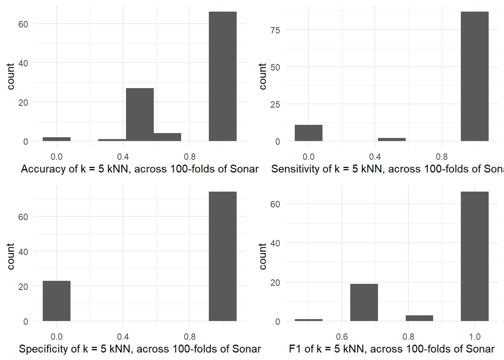

```r
df_ConfMatStats <- data.frame(acc = knn.accuracy_100, sens = sensitivity_100fold, spec = specificity_100fold, F1 = F1_100fold)
p0 <- df_ConfMatStats %>% ggplot()
p1 <- p0 + geom_histogram(bins = 7, aes(x = acc)) + xlab("Accuracy of k = 5 kNN, across 100-folds of Sonar")
p2 <- p0 + geom_histogram(bins = 7, aes(x = sens)) + xlab("Sensitivity of k = 5 kNN, across 100-folds of Sonar")
p3 <- p0 + geom_histogram(bins = 7, aes(x = spec)) + xlab("Specificity of k = 5 kNN, across 100-folds of Sonar")
p4 <- p0 + geom_histogram(bins = 7, aes(x = F1)) + xlab("F1 of k = 5 kNN, across 100-folds of Sonar")
grid.arrange(p1,p2,p3,p4,ncol = 2)
```

From the plots we see that while a good deal of the scores are placed around at $1,$ there are also signifigant specificities of $0$ amongst the $100$ folds, as well as accuracies of $50\%.$